# Session 2: Homework 1

MFA Stream B - Group35

2020-09-27

# 1 Where Do People Drink The Most Beer, Wine And Spirits?

```r
library(fivethirtyeight)
data(drinks)
```

Drinks data has multiple variable types which include characters (country), integers(beer_servings, spirit_servings, wine_servings) and double(total_litres_of_pure_alcohol, in decimal format). There are no missing values (n_missing=0).

```r
glimpse(drinks)
```

```
## Rows: 193
## Columns: 5
## $ country                      <chr> "Afghanistan", "Albania", "Algeria", "...
## $ beer_servings                <int> 0, 89, 25, 245, 217, 102, 193, 21, 261...
## $ spirit_servings              <int> 0, 132, 0, 138, 57, 128, 25, 179, 72, ...
## $ wine_servings                <int> 0, 54, 14, 312, 45, 45, 221, 11, 212, ...
## $ total_litres_of_pure_alcohol <dbl> 0.0, 4.9, 0.7, 12.4, 5.9, 4.9, 8.3, 3....
```

```r
skim(drinks)
```

Data summary

| Name | drinks |
| --- | --- |
| Number of rows | 193 |
| Number of columns | 5 |
| _______________________ |  |
| Column type frequency: |  |
| character | 1 |
| numeric | 4 |
| ________________________ |  |
| Group variables | None |

**Variable type: character**

| skim_variable | n_missing | complete_rate | min | max | empty | n_unique | whitespace |
| --- | --- | --- | --- | --- | --- | --- | --- |
| country | 0 | 1 | 3 | 28 | 0 | 193 | 0 |

**Variable type: numeric**

| skim_variable | n_missing | complete_rate | mean | sd | p0 | p25 | p50 | p75 | p100 | hist |
| --- | --- | --- | --- | --- | --- | --- | --- | --- | --- | --- |
| beer_servings | 0 | 1 | 106.16 | 101.14 | 0 | 20.0 | 76.0 | 188.0 | 376.0 | ▇▃▂▂▁ |
| spirit_servings | 0 | 1 | 80.99 | 88.28 | 0 | 4.0 | 56.0 | 128.0 | 438.0 | ▇▃▂▁▁ |
| wine_servings | 0 | 1 | 49.45 | 79.70 | 0 | 1.0 | 8.0 | 59.0 | 370.0 | ▇▁▁▁▁ |
| total_litres_of_pure_alcohol | 0 | 1 | 4.72 | 3.77 | 0 | 1.3 | 4.2 | 7.2 | 14.4 | ▇▃▅▃▁ |

Make a plot that shows the top 25 beer consuming countries

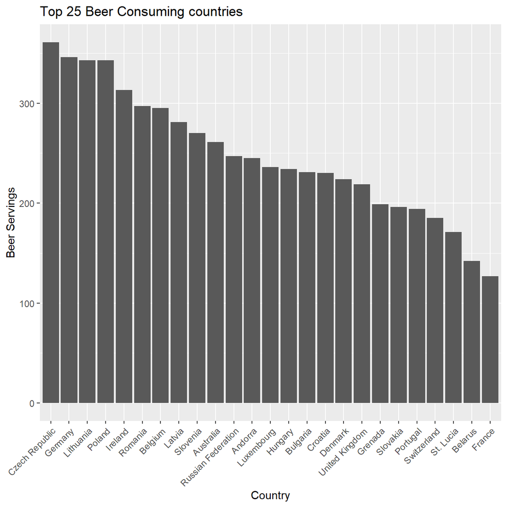

```r
beer_plot <- arrange(drinks, desc(beer_servings)) %>% top_n(25)

ggplot(data = beer_plot, mapping=aes(x=reorder(country, -beer_servings), y=beer_servings)) +
    geom_col() +
    labs(title = "Top 25 Beer Consuming countries",
       x = "Country",
       y = "Beer Servings") +
  theme(axis.text.x = element_text(angle = 45 , vjust = 1, hjust=1)) +
  NULL
```

Make a plot that shows the top 25 wine consuming countries

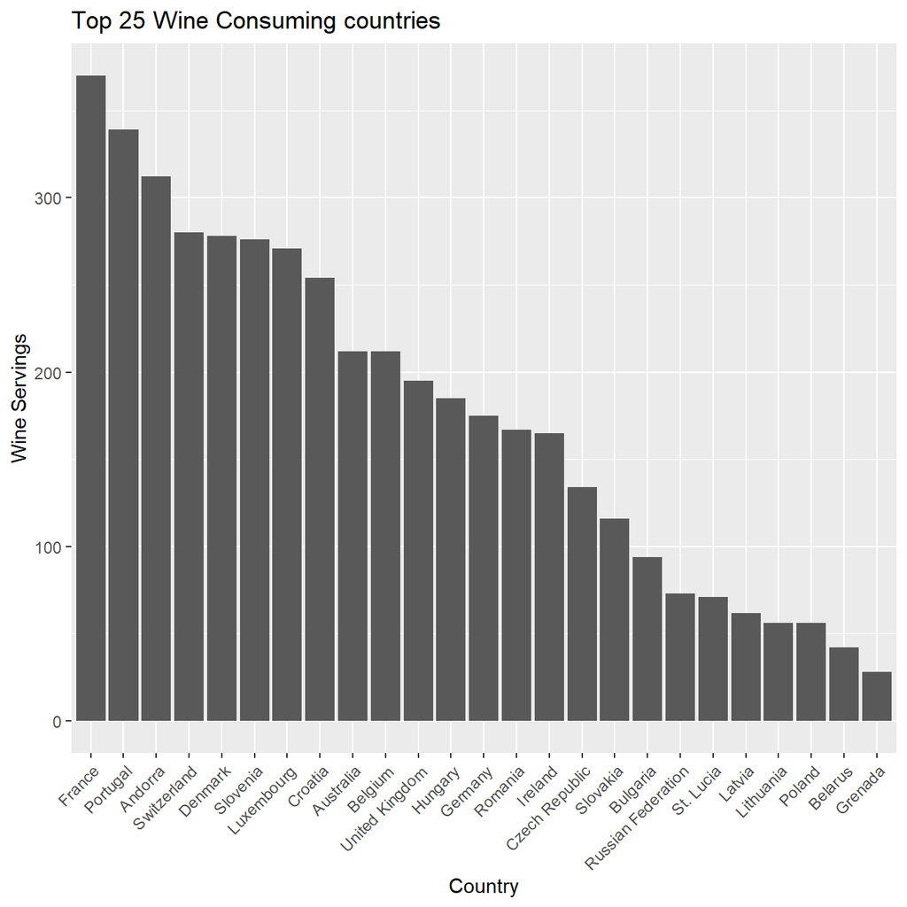

```r
wine_plot <- arrange(drinks, desc(wine_servings)) %>% top_n(25)

ggplot(data = wine_plot, mapping=aes(x=reorder(country, -wine_servings), y=wine_servings)) +
    geom_col() +
    labs(title = "Top 25 Wine Consuming countries",
       x = "Country",
       y = "Wine Servings") +
  theme(axis.text.x = element_text(angle = 45 , vjust = 1, hjust=1)) +
  NULL
```

Finally, make a plot that shows the top 25 spirit consuming countries

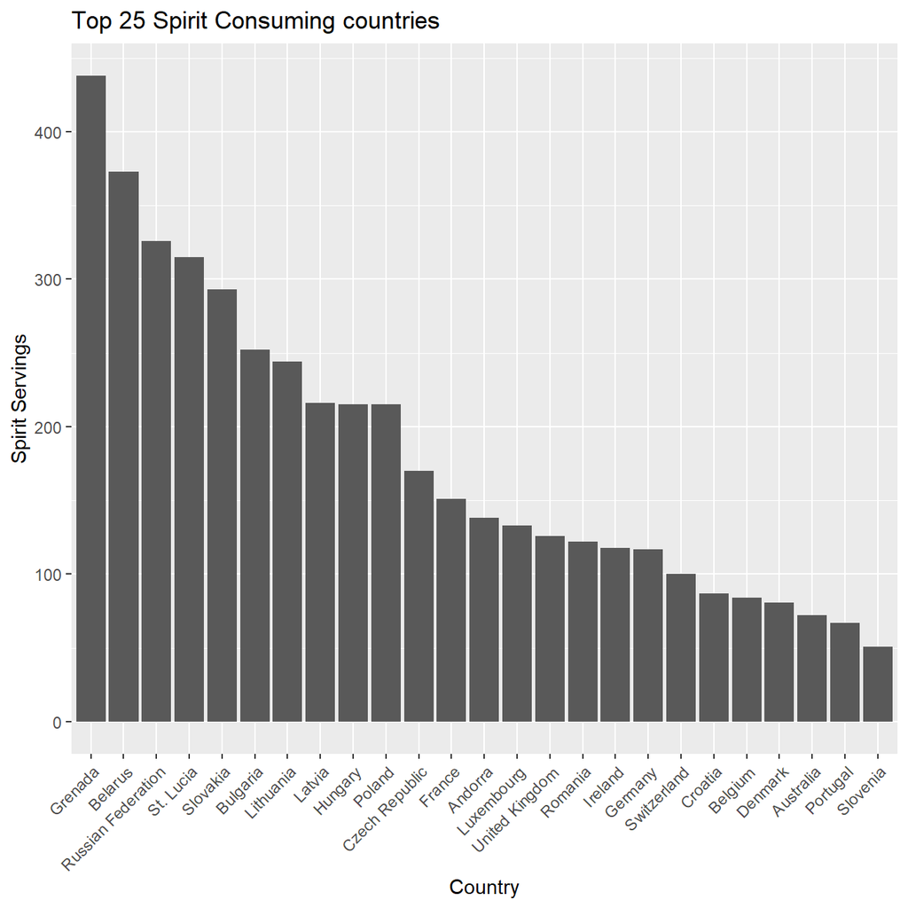

```r
spirit_plot <- arrange(drinks, desc(spirit_servings)) %>% top_n(25)

ggplot(data = spirit_plot, mapping=aes(x=reorder(country, -spirit_servings), y=spirit_servings)) +
    geom_col() +
    labs(title = "Top 25 Spirit Consuming countries",
       x = "Country",
       y = "Spirit Servings") +
  theme(axis.text.x = element_text(angle = 45 , vjust = 1, hjust=1)) +
  NULL
```

We can infer that in general, the most popular type of drinks is beer. This could be that beers are lighter in terms of pure alcohol. As a result, beer servings are higher compared to servings of the other two types of drinks since the body can tolerate a higher amount of lighter drinks.

# 2 Analysis of movies- IMDB dataset

```r
movies <- read_csv(here::here("data", "movies.csv"))
glimpse(movies)
```

```
## Rows: 2,961
## Columns: 11
## $ title               <chr> "Avatar", "Titanic", "Jurassic World", "The Ave...
## $ genre               <chr> "Action", "Drama", "Action", "Action", "Action"...
## $ director            <chr> "James Cameron", "James Cameron", "Colin Trevor...
## $ year                <dbl> 2009, 1997, 2015, 2012, 2008, 1999, 1977, 2015,...
## $ duration            <dbl> 178, 194, 124, 173, 152, 136, 125, 141, 164, 93...
## $ gross               <dbl> 7.61e+08, 6.59e+08, 6.52e+08, 6.23e+08, 5.33e+0...
## $ budget              <dbl> 2.37e+08, 2.00e+08, 1.50e+08, 2.20e+08, 1.85e+0...
## $ cast_facebook_likes <dbl> 4834, 45223, 8458, 87697, 57802, 37723, 13485, ...
## $ votes               <dbl> 886204, 793059, 418214, 995415, 1676169, 534658...
## $ reviews             <dbl> 3777, 2843, 1934, 2425, 5312, 3917, 1752, 1752,...
## $ rating              <dbl> 7.9, 7.7, 7.0, 8.1, 9.0, 6.5, 8.7, 7.5, 8.5, 7....
```

There are no missing values as n_missing is equal to 0 for all variables. However, there are 2,907 n_unique titles, compared to 2,961 rows of values. This indicates that there are 54 duplicate entries.

```r
skim(movies)
```

Data summary

| Name | movies |
| --- | --- |
| Number of rows | 2961 |
| Number of columns | 11 |
| _______________________ |  |
| Column type frequency: |  |
| character | 3 |
| numeric | 8 |
| ________________________ |  |
| Group variables | None |

**Variable type: character**

| skim_variable | n_missing | complete_rate | min | max | empty | n_unique | whitespace |
| --- | --- | --- | --- | --- | --- | --- | --- |
| title | 0 | 1 | 1 | 83 | 0 | 2907 | 0 |
| genre | 0 | 1 | 5 | 11 | 0 | 17 | 0 |
| director | 0 | 1 | 3 | 32 | 0 | 1366 | 0 |

**Variable type: numeric**

| skim_variable | n_missing | complete_rate | mean | sd | p0 | p25 | p50 | p75 | p100 | hist |
| --- | --- | --- | --- | --- | --- | --- | --- | --- | --- | --- |
| year | 0 | 1 | 2.00e+03 | 9.95e+00 | 1920.0 | 2.00e+03 | 2.00e+03 | 2.01e+03 | 2.02e+03 | ▁▁▁▂▇ |
| duration | 0 | 1 | 1.10e+02 | 2.22e+01 | 37.0 | 9.50e+01 | 1.06e+02 | 1.19e+02 | 3.30e+02 | ▃▇▁▁▁ |
| gross | 0 | 1 | 5.81e+07 | 7.25e+07 | 703.0 | 1.23e+07 | 3.47e+07 | 7.56e+07 | 7.61e+08 | ▇▁▁▁▁ |
| budget | 0 | 1 | 4.06e+07 | 4.37e+07 | 218.0 | 1.10e+07 | 2.60e+07 | 5.50e+07 | 3.00e+08 | ▇▂▁▁▁ |
| cast_facebook_likes | 0 | 1 | 1.24e+04 | 2.05e+04 | 0.0 | 2.24e+03 | 4.60e+03 | 1.69e+04 | 6.57e+05 | ▇▁▁▁▁ |
| votes | 0 | 1 | 1.09e+05 | 1.58e+05 | 5.0 | 1.99e+04 | 5.57e+04 | 1.33e+05 | 1.69e+06 | ▇▁▁▁▁ |
| reviews | 0 | 1 | 5.03e+02 | 4.94e+02 | 2.0 | 1.99e+02 | 3.64e+02 | 6.31e+02 | 5.31e+03 | ▇▁▁▁▁ |
| rating | 0 | 1 | 6.39e+00 | 1.05e+00 | 1.6 | 5.80e+00 | 6.50e+00 | 7.10e+00 | 9.30e+00 | ▁▁▆▇▁ |

Count of movies by genre, ranked in descending order

```r
count_genre <- movies %>% count(genre)

arrange(count_genre, desc(n))
```

```
## # A tibble: 17 x 2
##    genre           n
##    <chr>       <int>
##  1 Comedy        848
##  2 Action        738
##  3 Drama         498
##  4 Adventure     288
##  5 Crime         202
##  6 Biography     135
##  7 Horror        131
##  8 Animation      35
##  9 Fantasy        28
## 10 Documentary    25
## 11 Mystery        16
## 12 Sci-Fi          7
## 13 Family          3
## 14 Musical         2
## 15 Romance         2
## 16 Western         2
## 17 Thriller        1
```

Table with the average gross earning and budget by genre. Also ranked genres by `return_on_budget` (how many $ did a movie make at the box office for each $ of its budget) in descending order

```r
avg_geb <- movies %>% group_by(genre) %>% summarize(avg_earn = mean(gross), avg_budget = mean(budget))

avg_geb %>% mutate(return_on_budget = avg_earn/avg_budget) %>% arrange(desc(return_on_budget))
```

```
## # A tibble: 17 x 4
##    genre         avg_earn avg_budget return_on_budget
##    <chr>            <dbl>      <dbl>            <dbl>
##  1 Musical      92084000    3189500          28.9
##  2 Family      149160478.  14833333.         10.1
##  3 Western      20821884    3465000           6.01
##  4 Documentary  17353973.   5887852.          2.95
##  5 Horror       37713738.  13504916.          2.79
##  6 Fantasy      42408841.  17582143.          2.41
##  7 Comedy       42630552.  24446319.          1.74
##  8 Mystery      67533021.  39218750           1.72
##  9 Animation    98433792.  61701429.          1.60
## 10 Biography    45201805.  28543696.          1.58
## 11 Adventure    95794257.  66290069.          1.45
## 12 Drama        37465371.  26242933.          1.43
## 13 Crime        37502397.  26596169.          1.41
## 14 Romance      31264848.  25107500           1.25
## 15 Action       86583860.  71354888.          1.21
## 16 Sci-Fi       29788371.  27607143.          1.08
## 17 Thriller         2468     300000           0.00823
```

Top 15 directors who have created the highest gross revenue in the box office.

```r
top_15_dirs <- movies %>% group_by(director) %>%
  summarise(sum_gross = sum(gross, na.rm=TRUE), mean_gross=mean(gross, na.rm=TRUE),
            median_gross=median(gross, na.rm=TRUE), std_gross=sd(gross, na.rm=TRUE), count = n()) %>%
  arrange(desc(sum_gross)) %>% head(15)

top_15_dirs
```

```
## # A tibble: 15 x 6
##    director           sum_gross mean_gross median_gross  std_gross count
##    <chr>                  <dbl>      <dbl>        <dbl>      <dbl> <int>
##  1 Steven Spielberg  4014061704 174524422.   164435221  101421051.    23
##  2 Michael Bay       2231242537 171634041.   138396624  127161579.    13
##  3 Tim Burton        2071275480 129454718.    76519172  108726924.    16
##  4 Sam Raimi         2014600898 201460090.   234903076  162126632.    10
##  5 James Cameron     1909725910 318287652.   175562880. 309171337.     6
##  6 Christopher Nolan 1813227576 226653447    196667606. 187224133.     8
##  7 George Lucas      1741418480 348283696    380262555  146193880.     5
##  8 Robert Zemeckis   1619309108 124562239.   100853835   91300279.    13
##  9 Clint Eastwood    1378321100  72543216.    46700000   75487408.    19
## 10 Francis Lawrence  1358501971 271700394.   281666058  135437020.     5
## 11 Ron Howard        1335988092 111332341    101587923   81933761.    12
## 12 Gore Verbinski    1329600995 189942999.   123207194  154473822.     7
## 13 Andrew Adamson    1137446920 284361730    279680930. 120895765.     4
## 14 Shawn Levy        1129750988 102704635.    85463309   65484773.    11
## 15 Ridley Scott      1128857598  80632686.    47775715   68812285.    14
```

Distribution of ratings by genre

```r
ratings_by_genre <- movies %>% group_by(genre) %>%
  summarise(min_rating = min(rating, na.rm=TRUE), max_rating = max(rating, na.rm=TRUE), mean_rating=mean(rating, na.rm=TRUE),
            median_rating=median(rating, na.rm=TRUE), std_rating=sd(rating, na.rm=TRUE), count_rating= n())

ratings_by_genre
```

```
## # A tibble: 17 x 7
##    genre min_rating max_rating mean_rating median_rating std_rating count_rating
##    <chr>      <dbl>      <dbl>       <dbl>         <dbl>      <dbl>        <int>
##  1 Acti~        2.1        9          6.23          6.3       1.03           738
##  2 Adve~        2.3        8.6        6.51          6.6       1.09           288
##  3 Anim~        4.5        8          6.65          6.9       0.968           35
##  4 Biog~        4.5        8.9        7.11          7.2       0.760          135
##  5 Come~        1.9        8.8        6.11          6.2       1.02           848
##  6 Crime        4.8        9.3        6.92          6.9       0.849          202
##  7 Docu~        1.6        8.5        6.66          7.4       1.77            25
##  8 Drama        2.1        8.8        6.73          6.8       0.917          498
##  9 Fami~        5.7        7.9        6.5           5.9       1.22             3
## 10 Fant~        4.3        7.9        6.15          6.45      0.959           28
## 11 Horr~        3.6        8.5        5.83          5.9       1.01           131
## 12 Musi~        6.3        7.2        6.75          6.75      0.636            2
## 13 Myst~        4.6        8.5        6.86          6.9       0.882           16
## 14 Roma~        6.2        7.1        6.65          6.65      0.636            2
## 15 Sci-~        5          8.2        6.66          6.4       1.09             7
## 16 Thri~        4.8        4.8        4.8           4.8      NA                1
## 17 West~        4.1        7.3        5.70          5.70      2.26             2
```

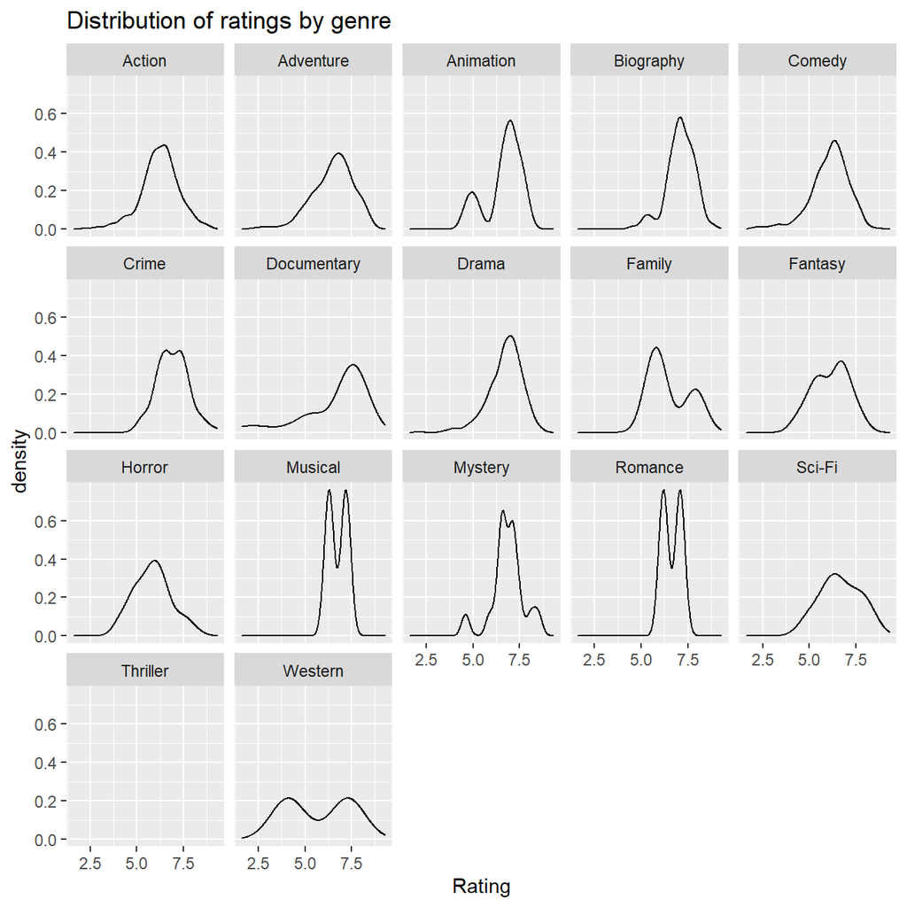

```r
ggplot(movies, aes(x = rating)) +
  geom_density() +
  facet_wrap(~genre) +
  labs(title = "Distribution of ratings by genre",
  x = "Rating") +
  NULL
```

Relationship between Gross Money and Cast Facebook likes

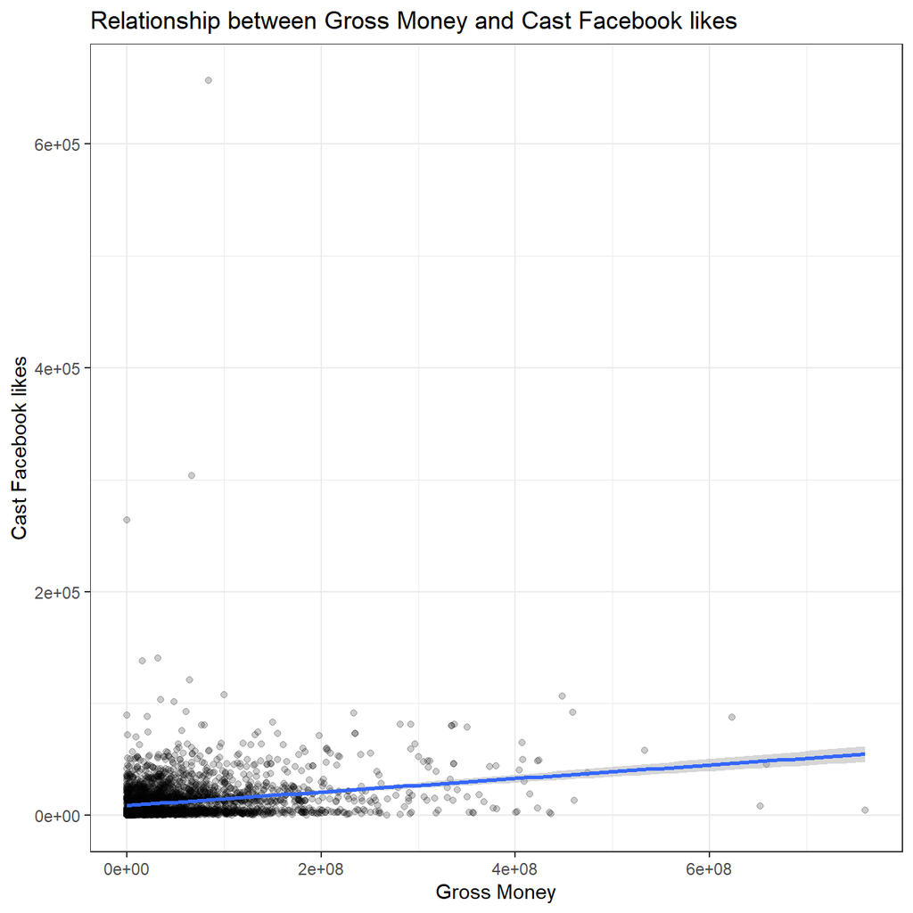

```r
ggplot(movies, aes(x=gross, y=cast_facebook_likes)) +
  geom_point(alpha=0.2) +
  geom_smooth(method = "lm") +
  labs(title = "Relationship between Gross Money and Cast Facebook likes",
       x = "Gross Money",
       y = "Cast Facebook likes") +
  theme_bw() +
  NULL
```

According to the above scatterplot, the number of cast facebook likes weakly predicts the gross revenue that the movie will generate, as the linear association between the number of facebook likes and gross money is weakly positive.

Relationship between Budget and Gross Money

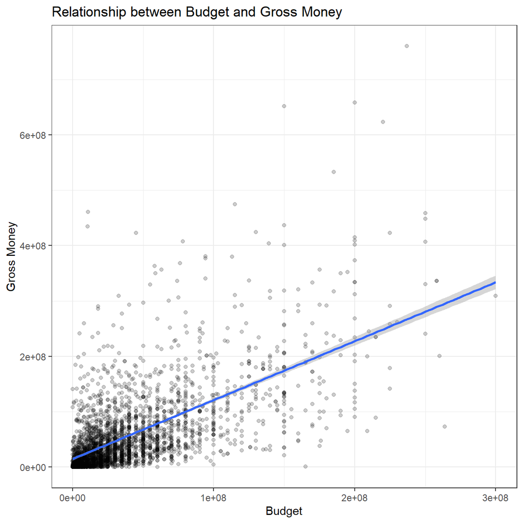

```r
ggplot(movies, aes(x=budget, y=gross)) +
  geom_point(alpha=0.2) +
  geom_smooth(method = "lm") +
  labs(title = "Relationship between Budget and Gross Money",
       x = "Budget",
       y = "Gross Money") +
  theme_bw() +
  NULL
```

According to the scatterplot, budget and gross revenue are positively correlated, therefore budget is likely to be a good predictor of how much money a movie will make at the box office.

Relationship between Ratings and Gross Money

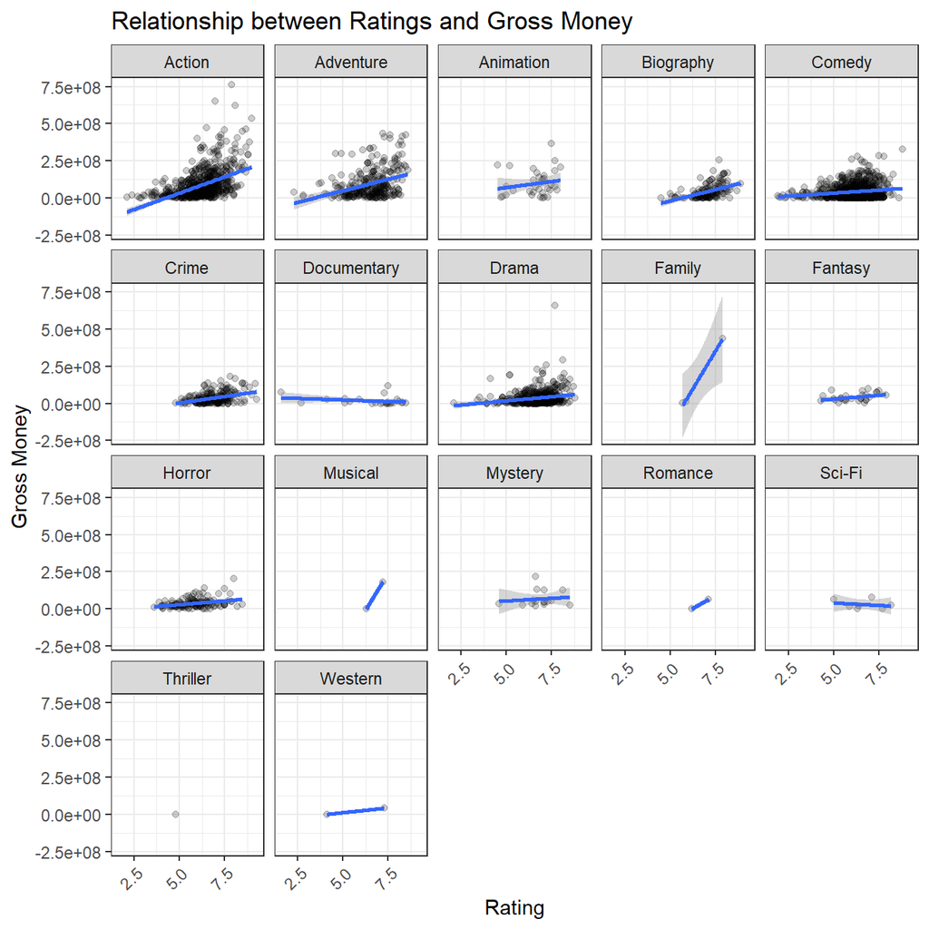

```r
ggplot(movies, aes(x=rating, y=gross)) +
  geom_point(alpha=0.2) +
  facet_wrap(~genre) +
  geom_smooth(method = "lm") +
  labs(title = "Relationship between Ratings and Gross Money",
       x = "Rating",
       y = "Gross Money") +
  theme_bw() +
  theme(axis.text.x = element_text(angle = 45 , vjust = 1, hjust=1)) +
  NULL
```

According to the scatterplots produced, IMDB ratings and gross revenue correlation differs between genres. Ratings and gross revenue are only positively correlated if the movie is part of Action, Adventure, Animation, Biography, Comedy, Crime, Drama, Family, Fantasy, Horror, Musical, Mystery, Romance and Western. However, if the movie is part of the Documentary and Sci-fi genres, then the correlation seems negative and ratings are a weak predictor of gross revenue. Finally, it would help our analysis if we had more data for Thriller, Romance, Musical and Family genres as it is hard to draw a conclusion from a few observations.

# 3 Returns of financial stocks

```r
nyse <- read_csv(here::here("data","nyse.csv"))
```

Number of companies per sector, in descending order

```r
# YOUR CODE GOES HERE
glimpse(nyse)
```

```
## Rows: 508
## Columns: 6
## $ symbol        <chr> "MMM", "ABB", "ABT", "ABBV", "ACN", "AAP", "AFL", "A"...
## $ name          <chr> "3M Company", "ABB Ltd", "Abbott Laboratories", "AbbV...
## $ ipo_year      <chr> "n/a", "n/a", "n/a", "2012", "2001", "n/a", "n/a", "1...
## $ sector        <chr> "Health Care", "Consumer Durables", "Health Care", "H...
## $ industry      <chr> "Medical/Dental Instruments", "Electrical Products", ...
## $ summary_quote <chr> "https://www.nasdaq.com/symbol/mmm", "https://www.nas...
```

```r
companies_per_sector <- nyse %>% group_by(sector) %>% count() %>% arrange(desc(n))
companies_per_sector
```

```
## # A tibble: 12 x 2
## # Groups:   sector [12]
##    sector                    n
##    <chr>                 <int>
##  1 Finance                  97
##  2 Consumer Services        79
##  3 Public Utilities         60
##  4 Capital Goods            45
##  5 Health Care              45
##  6 Energy                   42
##  7 Technology               40
##  8 Basic Industries         39
##  9 Consumer Non-Durables    31
## 10 Miscellaneous            12
## 11 Transportation           10
## 12 Consumer Durables         8
```

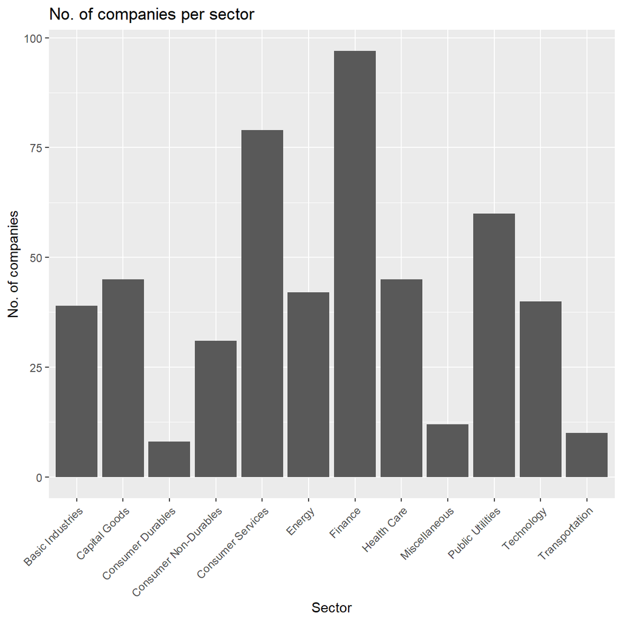

```r
ggplot(companies_per_sector, aes(x=sector, y=n)) +
  geom_col() +
  labs(title = "No. of companies per sector",
       x = "Sector",
       y = "No. of companies") +
  theme(axis.text.x = element_text(angle = 45 , vjust = 1, hjust=1)) +
  NULL
```

```r
djia_url <- "https://en.wikipedia.org/wiki/Dow_Jones_Industrial_Average"

#get tables that exist on URL
tables <- djia_url %>%
  read_html() %>%
  html_nodes(css="table")


# parse HTML tables into a dataframe called djia.
# Use purr::map() to create a list of all tables in URL
djia <- map(tables, . %>%
               html_table(fill=TRUE)%>%
               clean_names())


# constituents
table1 <- djia[[2]] %>% # the second table on the page contains the ticker symbols
  mutate(date_added = ymd(date_added),

         # if a stock is listed on NYSE, its symbol is, e.g., NYSE: MMM
         # We will get prices from yahoo finance which requires just the ticker

         # if symbol contains "NYSE*", the * being a wildcard
         # then we jsut drop the first 6 characters in that string
         ticker = ifelse(str_detect(symbol, "NYSE*"),
                          str_sub(symbol,7,11),
                          symbol)
         )

# we need a vector of strings with just the 30 tickers + SPY
tickers <- table1 %>%
  select(ticker) %>%
  pull() %>% # pull() gets them as a sting of characters
  c("SPY") # and lets us add SPY, the SP500 ETF
```

```r
myStocks <- tickers %>%
  tq_get(get  = "stock.prices",
         from = "2000-01-01",
         to   = "2020-08-31") %>%
  group_by(symbol)

glimpse(myStocks) # examine the structure of the resulting data frame
```

```
## Rows: 153,121
## Columns: 8
## Groups: symbol [31]
## $ symbol   <chr> "MMM", "MMM", "MMM", "MMM", "MMM", "MMM", "MMM", "MMM", "M...
## $ date     <date> 2000-01-03, 2000-01-04, 2000-01-05, 2000-01-06, 2000-01-0...
## $ open     <dbl> 48.0, 46.4, 45.6, 47.2, 50.6, 50.2, 50.4, 51.0, 50.7, 50.4...
## $ high     <dbl> 48.2, 47.4, 48.1, 51.2, 51.9, 51.8, 51.2, 51.8, 50.9, 50.5...
## $ low      <dbl> 47.0, 45.3, 45.6, 47.2, 50.0, 50.0, 50.2, 50.4, 50.2, 49.5...
## $ close    <dbl> 47.2, 45.3, 46.6, 50.4, 51.4, 51.1, 50.2, 50.4, 50.4, 49.7...
## $ volume   <dbl> 2173400, 2713800, 3699400, 5975800, 4101200, 3863800, 2357...
## $ adjusted <dbl> 28.1, 26.9, 27.7, 30.0, 30.5, 30.4, 29.9, 30.0, 30.0, 29.5...
```

Below we are calculating daily, monthly, and yearly returns.

```r
#calculate daily returns
myStocks_returns_daily <- myStocks %>%
  tq_transmute(select     = adjusted,
               mutate_fun = periodReturn,
               period     = "daily",
               type       = "log",
               col_rename = "daily_returns",
               cols = c(nested.col))

#calculate monthly  returns
myStocks_returns_monthly <- myStocks %>%
  tq_transmute(select     = adjusted,
               mutate_fun = periodReturn,
               period     = "monthly",
               type       = "arithmetic",
               col_rename = "monthly_returns",
               cols = c(nested.col))

#calculate yearly returns
myStocks_returns_annual <- myStocks %>%
  group_by(symbol) %>%
  tq_transmute(select     = adjusted,
               mutate_fun = periodReturn,
               period     = "yearly",
               type       = "arithmetic",
               col_rename = "yearly_returns",
               cols = c(nested.col))
```

Summary of monthly returns since 2017-01-01 for each of the stocks and `SPY`.

```r
# YOUR CODE GOES HERE

glimpse(myStocks_returns_monthly)
```

```
## Rows: 7,307
## Columns: 3
## Groups: symbol [31]
## $ symbol          <chr> "MMM", "MMM", "MMM", "MMM", "MMM", "MMM", "MMM", "M...
## $ date            <date> 2000-01-31, 2000-02-29, 2000-03-31, 2000-04-28, 20...
## $ monthly_returns <dbl> -0.00795, -0.05198, 0.00425, -0.02188, -0.00368, -0...
```

```r
monthly_return_summary <- myStocks_returns_monthly %>% filter(date >= "2017-01-01") %>% group_by(symbol) %>%
  summarise(min_return = min(monthly_returns, na.rm = TRUE),
            max_return = max(monthly_returns, na.rm = TRUE),
            median_return = median(monthly_returns, na.rm = TRUE),
            mean_return = mean(monthly_returns, na.rm = TRUE),
            sd_return = sd(monthly_returns, na.rm = TRUE))
monthly_return_summary
```

```
## # A tibble: 31 x 6
##    symbol min_return max_return median_return mean_return sd_return
##    <chr>       <dbl>      <dbl>         <dbl>       <dbl>     <dbl>
##  1 AAPL       -0.181     0.200        0.0513     0.0387      0.0873
##  2 AMGN       -0.104     0.180        0.0235     0.0171      0.0664
##  3 AXP        -0.221     0.0988       0.0150     0.0109      0.0639
##  4 BA         -0.458     0.257        0.0250     0.0124      0.120
##  5 CAT        -0.199     0.138        0.0318     0.0151      0.0742
##  6 CRM        -0.155     0.391        0.0403     0.0350      0.0850
##  7 CSCO       -0.155     0.130        0.0185     0.0125      0.0673
##  8 CVX        -0.224     0.270        0.00173   -0.000926    0.0748
##  9 DIS        -0.179     0.234       -0.00208    0.00967     0.0750
## 10 DOW        -0.276     0.255        0.0456     0.00898     0.128
## # ... with 21 more rows
```

Desnity Plot for each of the stocks

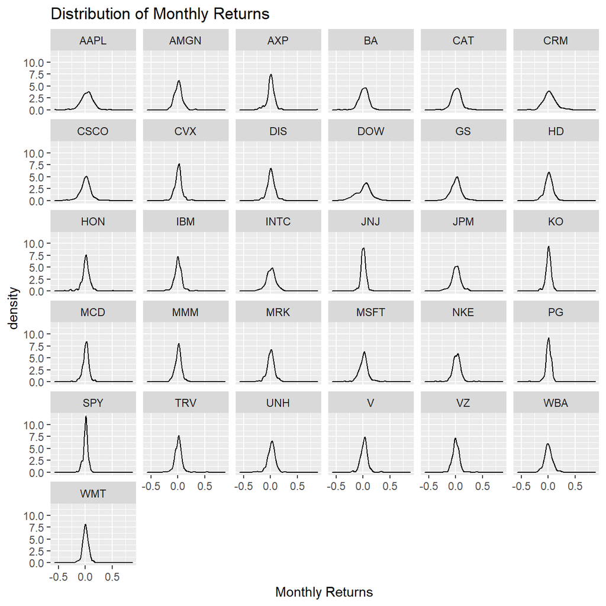

```r
# YOUR CODE GOES HERE

ggplot(myStocks_returns_monthly, aes(x = monthly_returns)) +
  geom_density() +
  facet_wrap(~symbol) +
  labs(title = "Distribution of Monthly Returns",
  x = "Monthly Returns") +
  NULL
```

Expected monthly return (mean) of a stock vs the risk (standard deviation)

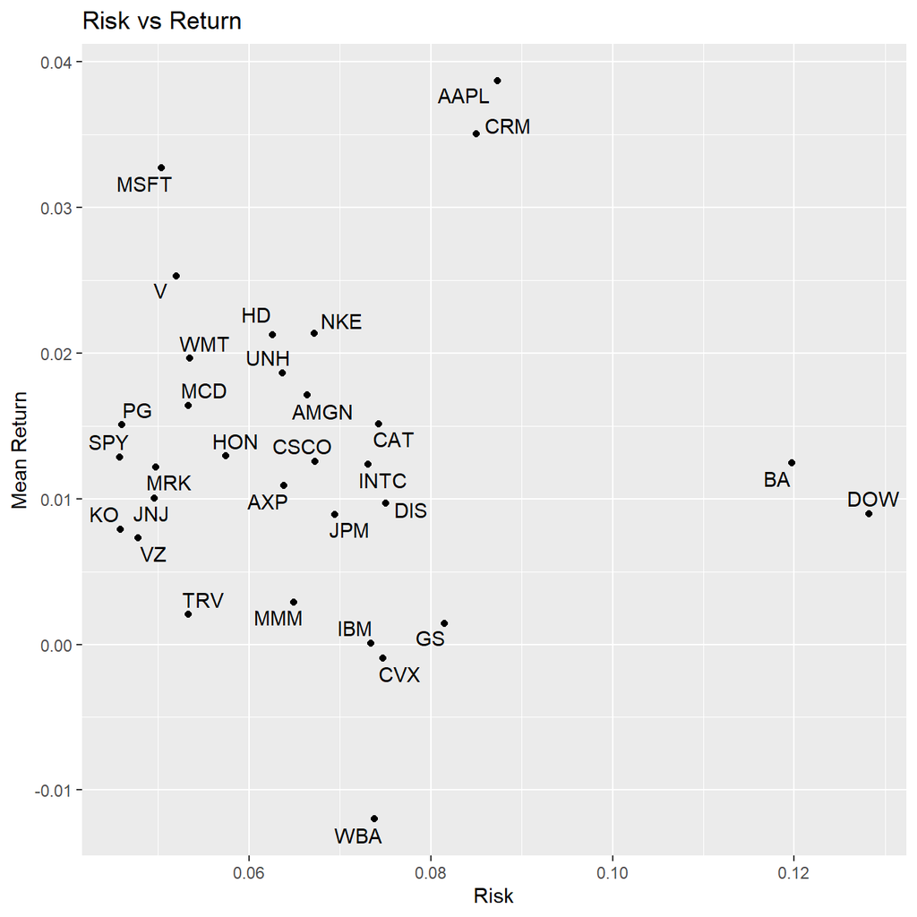

```r
# YOUR CODE GOES HERE

ggplot(monthly_return_summary, aes(x = sd_return, y = mean_return)) +
  geom_point() +
  geom_text_repel(label = monthly_return_summary$symbol) +
  labs(title = "Risk vs Return",
       x = "Risk",
       y = "Mean Return") +
  NULL
```

This plot shows a positive correlation between risk and return. However, a few stocks such as WBA and CVX have lower expected returns while being riskier.

# 4 On your own: IBM HR Analytics

Loading the data

```r
hr_dataset <- read_csv(here::here("data", "datasets_1067_1925_WA_Fn-UseC_-HR-Employee-Attrition.csv"))
glimpse(hr_dataset)
```

```
## Rows: 1,470
## Columns: 35
## $ Age                      <dbl> 41, 49, 37, 33, 27, 32, 59, 30, 38, 36, 35...
## $ Attrition                <chr> "Yes", "No", "Yes", "No", "No", "No", "No"...
## $ BusinessTravel           <chr> "Travel_Rarely", "Travel_Frequently", "Tra...
## $ DailyRate                <dbl> 1102, 279, 1373, 1392, 591, 1005, 1324, 13...
## $ Department               <chr> "Sales", "Research & Development", "Resear...
## $ DistanceFromHome         <dbl> 1, 8, 2, 3, 2, 2, 3, 24, 23, 27, 16, 15, 2...
## $ Education                <dbl> 2, 1, 2, 4, 1, 2, 3, 1, 3, 3, 3, 2, 1, 2, ...
## $ EducationField           <chr> "Life Sciences", "Life Sciences", "Other",...
## $ EmployeeCount            <dbl> 1, 1, 1, 1, 1, 1, 1, 1, 1, 1, 1, 1, 1, 1, ...
## $ EmployeeNumber           <dbl> 1, 2, 4, 5, 7, 8, 10, 11, 12, 13, 14, 15, ...
## $ EnvironmentSatisfaction  <dbl> 2, 3, 4, 4, 1, 4, 3, 4, 4, 3, 1, 4, 1, 2, ...
## $ Gender                   <chr> "Female", "Male", "Male", "Female", "Male"...
## $ HourlyRate               <dbl> 94, 61, 92, 56, 40, 79, 81, 67, 44, 94, 84...
```

[output cut: 22 more lines]

Cleaning the data

```r
hr_cleaned <- hr_dataset %>%
  clean_names() %>%
  mutate(
    education = case_when(
      education == 1 ~ "Below College",
      education == 2 ~ "College",
      education == 3 ~ "Bachelor",
      education == 4 ~ "Master",
      education == 5 ~ "Doctor"
    ),
    environment_satisfaction = case_when(
      environment_satisfaction == 1 ~ "Low",
      environment_satisfaction == 2 ~ "Medium",
      environment_satisfaction == 3 ~ "High",
      environment_satisfaction == 4 ~ "Very High"
    ),
    job_satisfaction = case_when(
      job_satisfaction == 1 ~ "Low",
      job_satisfaction == 2 ~ "Medium",
      job_satisfaction == 3 ~ "High",
      job_satisfaction == 4 ~ "Very High"
    ),
    performance_rating = case_when(
      performance_rating == 1 ~ "Low",
      performance_rating == 2 ~ "Good",
      performance_rating == 3 ~ "Excellent",
      performance_rating == 4 ~ "Outstanding"
    ),
    work_life_balance = case_when(
      work_life_balance == 1 ~ "Bad",
      work_life_balance == 2 ~ "Good",
      work_life_balance == 3 ~ "Better",
      work_life_balance == 4 ~ "Best"
    )
  ) %>%
  select(age, attrition, daily_rate, department,
         distance_from_home, education,
         gender, job_role,environment_satisfaction,
         job_satisfaction, marital_status,
         monthly_income, num_companies_worked, percent_salary_hike,
         performance_rating, total_working_years,
         work_life_balance, years_at_company,
         years_since_last_promotion)
```

1. Attrition Rate of the company:

```r
glimpse(hr_cleaned)
```

```
## Rows: 1,470
## Columns: 19
## $ age                        <dbl> 41, 49, 37, 33, 27, 32, 59, 30, 38, 36, ...
## $ attrition                  <chr> "Yes", "No", "Yes", "No", "No", "No", "N...
## $ daily_rate                 <dbl> 1102, 279, 1373, 1392, 591, 1005, 1324, ...
## $ department                 <chr> "Sales", "Research & Development", "Rese...
## $ distance_from_home         <dbl> 1, 8, 2, 3, 2, 2, 3, 24, 23, 27, 16, 15,...
## $ education                  <chr> "College", "Below College", "College", "...
## $ gender                     <chr> "Female", "Male", "Male", "Female", "Mal...
## $ job_role                   <chr> "Sales Executive", "Research Scientist",...
## $ environment_satisfaction   <chr> "Medium", "High", "Very High", "Very Hig...
## $ job_satisfaction           <chr> "Very High", "Medium", "High", "High", "...
## $ marital_status             <chr> "Single", "Married", "Single", "Married"...
## $ monthly_income             <dbl> 5993, 5130, 2090, 2909, 3468, 3068, 2670...
## $ num_companies_worked       <dbl> 8, 1, 6, 1, 9, 0, 4, 1, 0, 6, 0, 0, 1, 0...
## $ percent_salary_hike        <dbl> 11, 23, 15, 11, 12, 13, 20, 22, 21, 13, ...
## $ performance_rating         <chr> "Excellent", "Outstanding", "Excellent",...
## $ total_working_years        <dbl> 8, 10, 7, 8, 6, 8, 12, 1, 10, 17, 6, 10,...
## $ work_life_balance          <chr> "Bad", "Better", "Better", "Better", "Be...
## $ years_at_company           <dbl> 6, 10, 0, 8, 2, 7, 1, 1, 9, 7, 5, 9, 5, ...
## $ years_since_last_promotion <dbl> 0, 1, 0, 3, 2, 3, 0, 0, 1, 7, 0, 0, 4, 1...
```

```r
employees_left <- sum(hr_cleaned$attrition == "Yes")
employees_left
```

```
## [1] 237
```

```r
total_employees <- count(hr_cleaned)
total_employees
```

```
## # A tibble: 1 x 1
##       n
##   <int>
## 1  1470
```

```r
attrition_rate <-  employees_left / total_employees * 100.0
attrition_rate
```

```
##      n
## 1 16.1
```

2. Distribution of various variables:

The age variable seems the closest to normal, with a mean and median value very close to each other.

```r
cols <- c('age', 'years_at_company', 'monthly_income', 'years_since_last_promotion')
row_names <- c('min', 'max', 'mean', 'median', 'sd')
subset_data <- hr_cleaned[, cols]


summary_vals <- subset_data %>% summarise_each(funs(min))
summary_vals <- append(summary_vals, subset_data %>% summarise_each(funs(max)))
summary_vals <- append(summary_vals, subset_data %>% summarise_each(funs(mean)))
summary_vals <- append(summary_vals, subset_data %>% summarise_each(funs(median)))
summary_vals <- append(summary_vals, subset_data %>% summarise_each(funs(sd)))

summary_matrix <- matrix(summary_vals, nrow = 5, dimnames = list(row_names, cols), byrow = TRUE)
summary_matrix
```

```
##        age  years_at_company monthly_income years_since_last_promotion
## min    18   0                1009           0
## max    60   40               19999          15
## mean   36.9 7.01             6503           2.19
## median 36   5                4919           1
## sd     9.14 6.13             4708           3.22
```

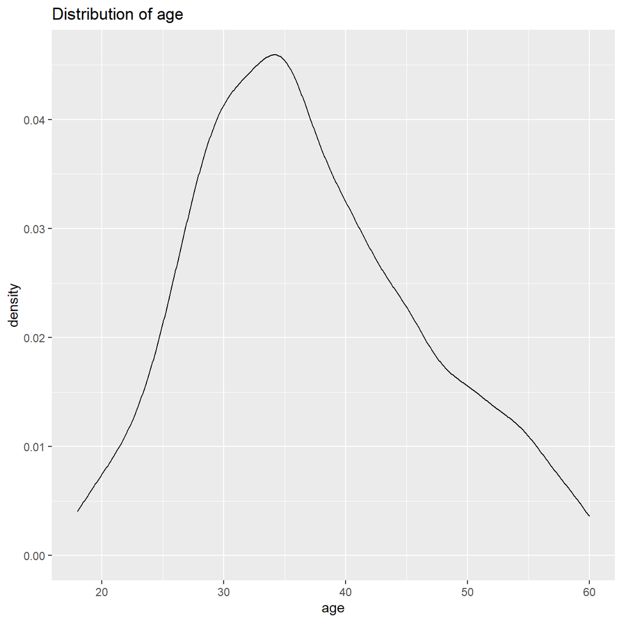

```r
ggplot(hr_cleaned, aes(x=age)) + labs(title = "Distribution of age", x = "age") +
  geom_density() + NULL
```

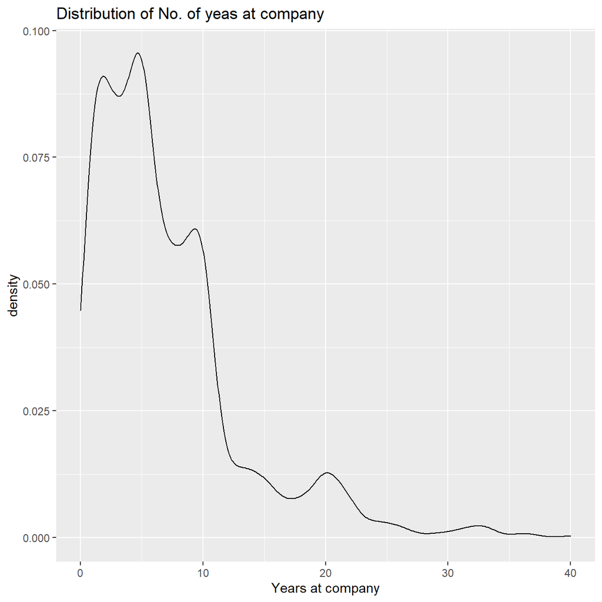

```r
ggplot(hr_cleaned, aes(x=years_at_company)) + labs(title = "Distribution of No. of yeas at company", x = "Years at company") +
  geom_density() + NULL
```

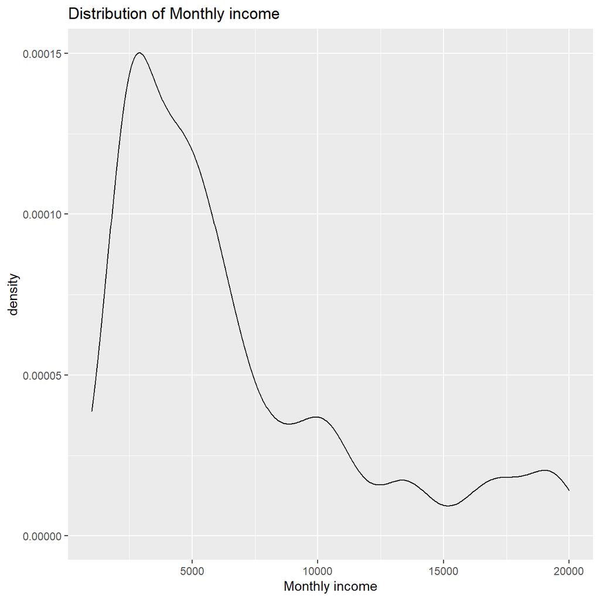

```r
ggplot(hr_cleaned, aes(x=monthly_income)) + labs(title = "Distribution of Monthly income", x = "Monthly income") +
  geom_density() + NULL
```

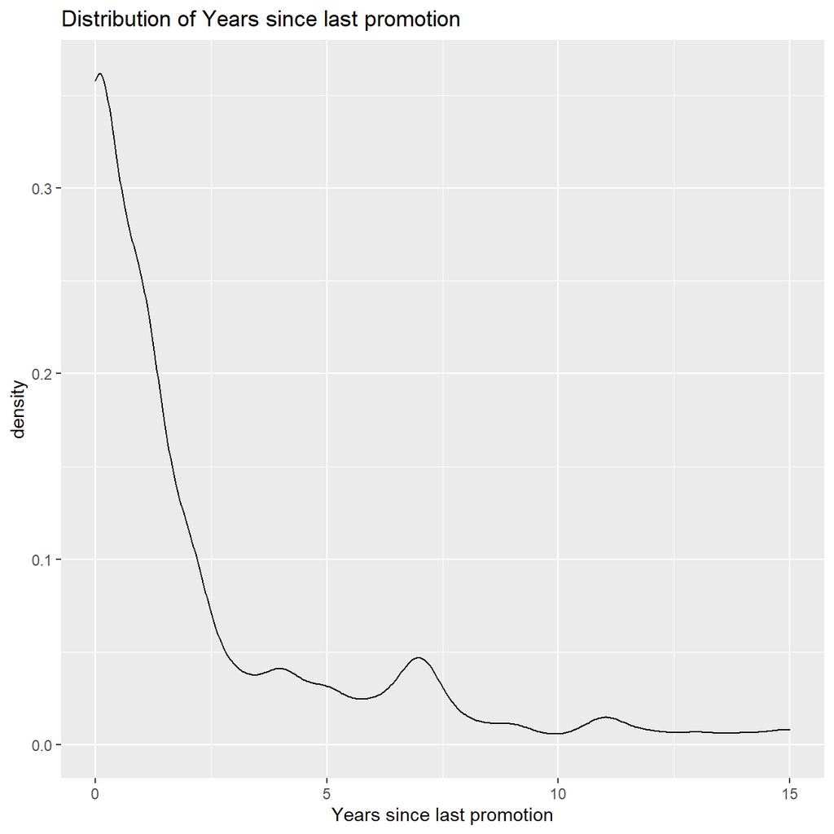

```r
ggplot(hr_cleaned, aes(x=years_since_last_promotion)) + labs(title = "Distribution of Years since last promotion",
                                                             x = "Years since last promotion") +
  geom_density() + NULL
```

3. Distribution of `job_satisfaction` and `work_life_balance`:

```r
job_satisfaction_dist <- hr_cleaned %>% group_by(job_satisfaction) %>% count() %>% mutate(prcnt = n/nrow(hr_cleaned)*100.0)
job_satisfaction_dist
```

```
## # A tibble: 4 x 3
## # Groups:   job_satisfaction [4]
##   job_satisfaction     n prcnt
##   <chr>            <int> <dbl>
## 1 High               442  30.1
## 2 Low                289  19.7
## 3 Medium             280  19.0
## 4 Very High          459  31.2
```

```r
work_lif_bal_dist <- hr_cleaned %>% group_by(work_life_balance) %>% count() %>% mutate(prcnt = n/nrow(hr_cleaned)*100.0)
work_lif_bal_dist
```

```
## # A tibble: 4 x 3
## # Groups:   work_life_balance [4]
##   work_life_balance     n prcnt
##   <chr>             <int> <dbl>
## 1 Bad                  80  5.44
## 2 Best                153 10.4
## 3 Better              893 60.7
## 4 Good                344 23.4
```

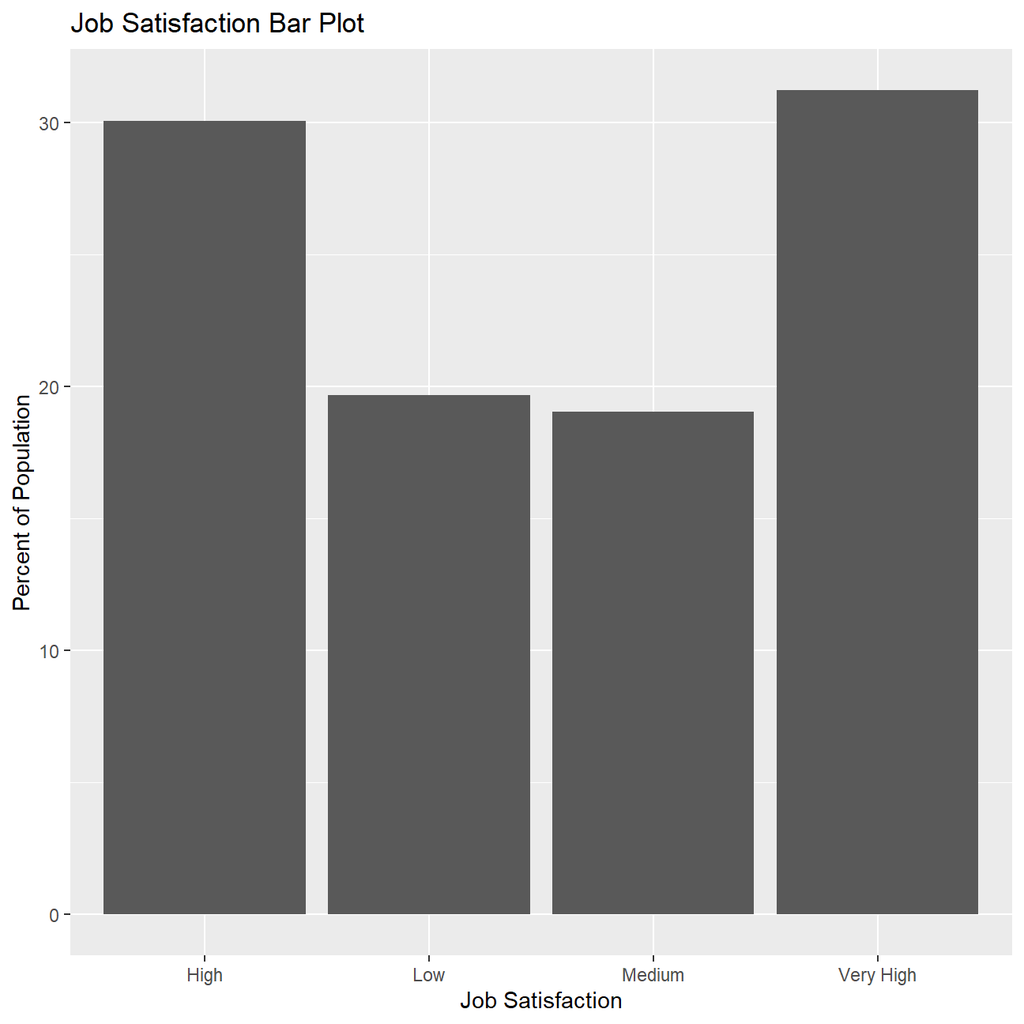

```r
ggplot(job_satisfaction_dist, aes(x = job_satisfaction, y = prcnt)) +
  geom_col() +
  labs(title = "Job Satisfaction Bar Plot",
       x = "Job Satisfaction",
       y = "Percent of Population") +
  NULL
```

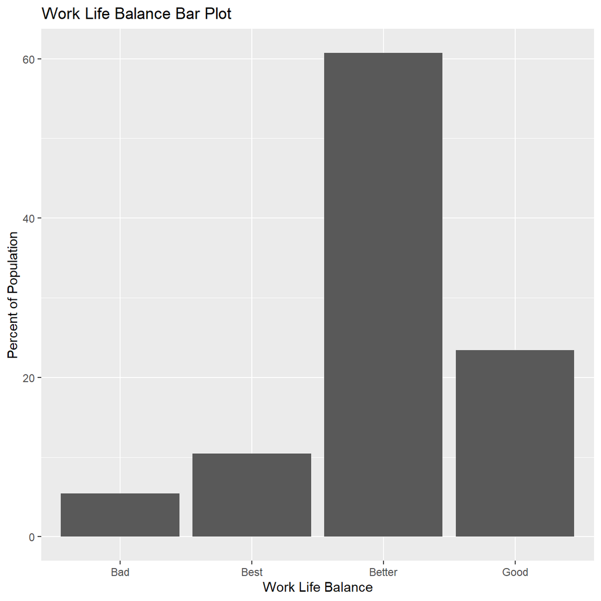

```r
ggplot(work_lif_bal_dist, aes(x = work_life_balance, y = prcnt)) +
  geom_col() +
  labs(title = "Work Life Balance Bar Plot",
       x = "Work Life Balance",
       y = "Percent of Population") +
  NULL
```

4. Relationship between monthly income and education, and Monthly income and gender:

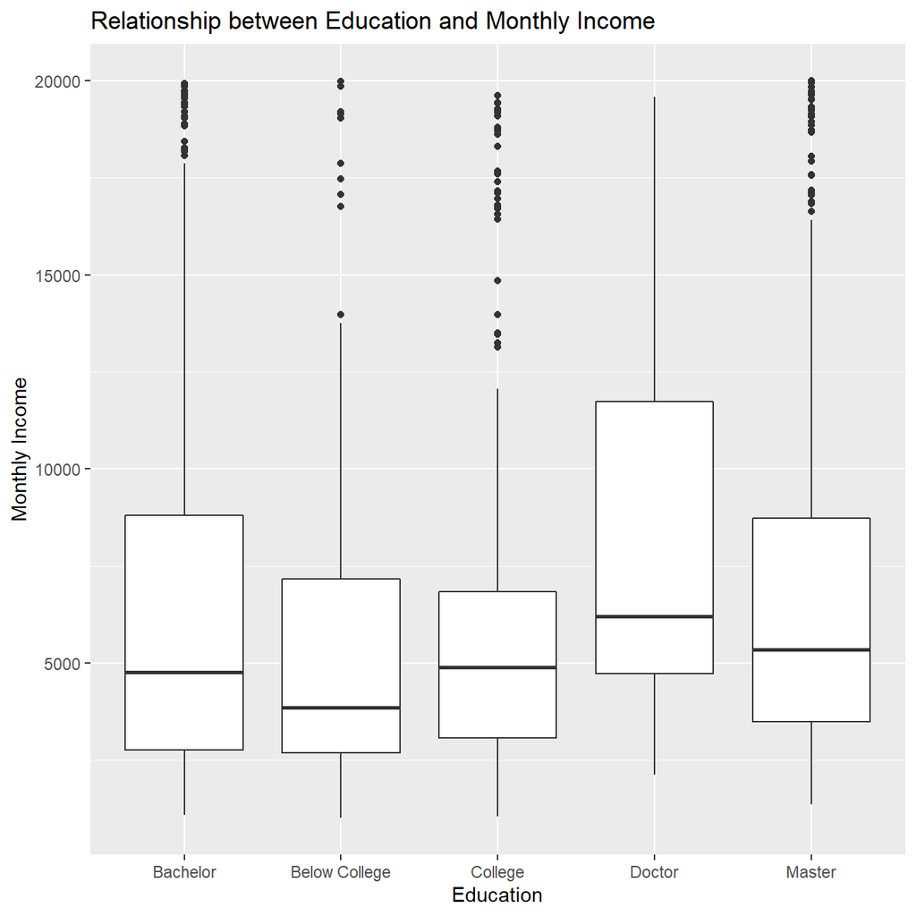

```r
ggplot(hr_cleaned, aes(x=education, y=monthly_income)) +
  geom_boxplot() +
  labs(title = "Relationship between Education and Monthly Income",
       x = "Education",
       y = "Monthly Income") +
  NULL
```

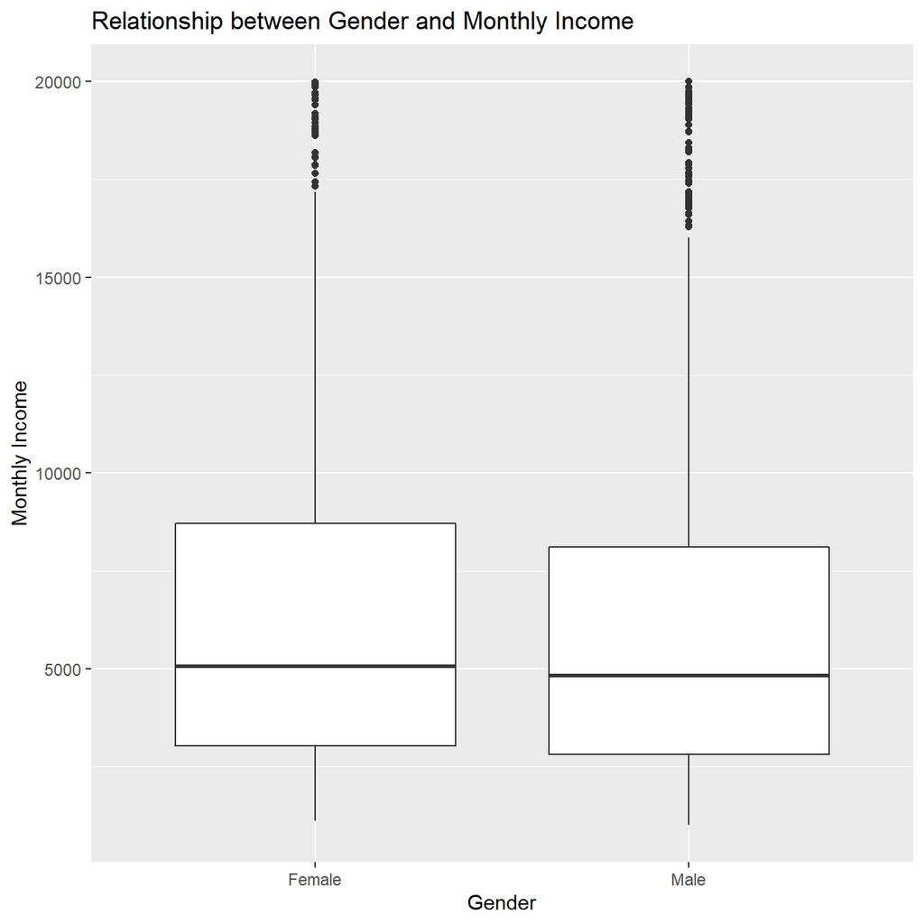

```r
ggplot(hr_cleaned, aes(x=gender, y=monthly_income)) +
  geom_boxplot() +
  labs(title = "Relationship between Gender and Monthly Income",
       x = "Gender",
       y = "Monthly Income") +
  NULL
```

There seems to be a slight relationship between education and monthly income as the higher the education level, the higher monthly income tends to be.However, the dataset does not seem to show any substantial relationship between gender and monthly income, with both male and female showing similar monthly income distribution.

5. Boxplot of income vs job role:

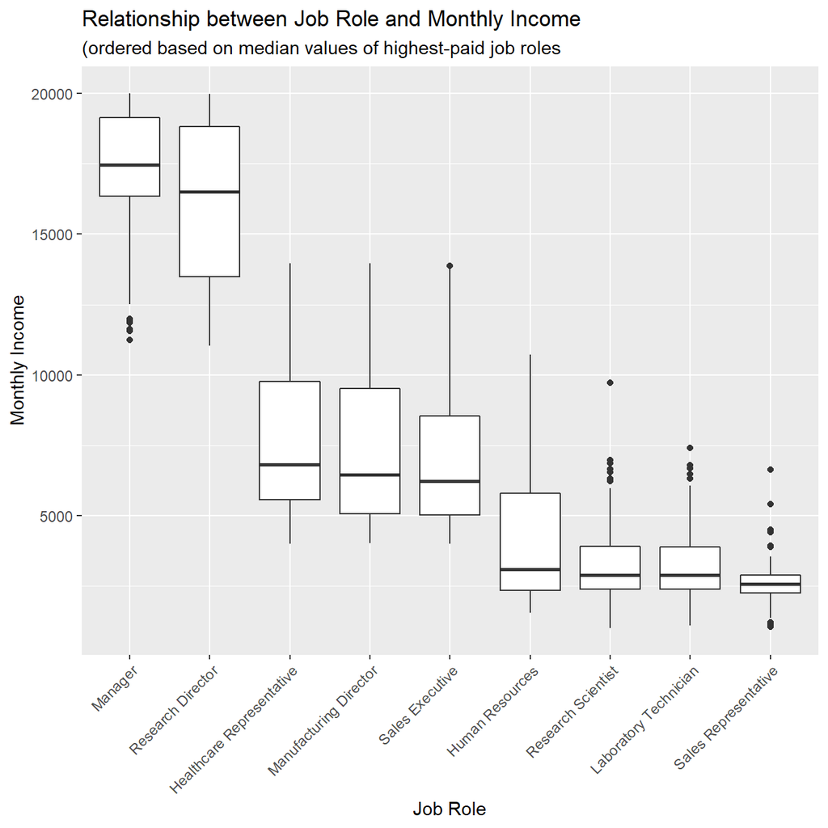

```r
new_order <- with(hr_cleaned, reorder(job_role, -monthly_income, median , na.rm=T))

ggplot(hr_cleaned, aes(x=new_order, y=monthly_income)) +
  geom_boxplot() +
  labs(title = "Relationship between Job Role and Monthly Income",
       subtitle = "(ordered based on median values of highest-paid job roles",
       x = "Job Role",
       y = "Monthly Income") +
  theme(axis.text.x = element_text(angle = 45 , vjust = 1, hjust=1)) +
  NULL
```

6. Median income by education level:

```r
income_vs_education <- hr_cleaned %>% group_by(education) %>%
  summarise(min_income = min(monthly_income),
            max_income = max(monthly_income),
            mean_income = mean(monthly_income),
            median_income = median(monthly_income))

income_vs_education
```

```
## # A tibble: 5 x 5
##   education     min_income max_income mean_income median_income
##   <chr>              <dbl>      <dbl>       <dbl>         <dbl>
## 1 Bachelor            1081      19926       6517.         4762
## 2 Below College       1009      19973       5641.         3849
## 3 College             1051      19613       6227.         4892.
## 4 Doctor              2127      19586       8278.         6203
## 5 Master              1359      19999       6832.         5342.
```

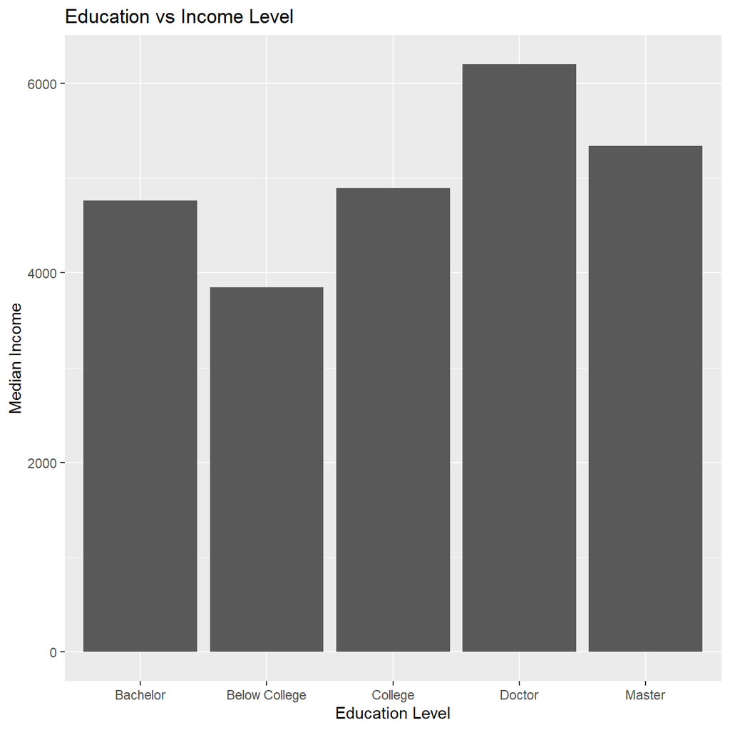

```r
ggplot(income_vs_education, aes(x=education, y=median_income)) +
  geom_col() +
  labs(title = "Education vs Income Level",
       x = "Education Level",
       y = "Median Income") +
  NULL
```

7. Distribution of income by education level:

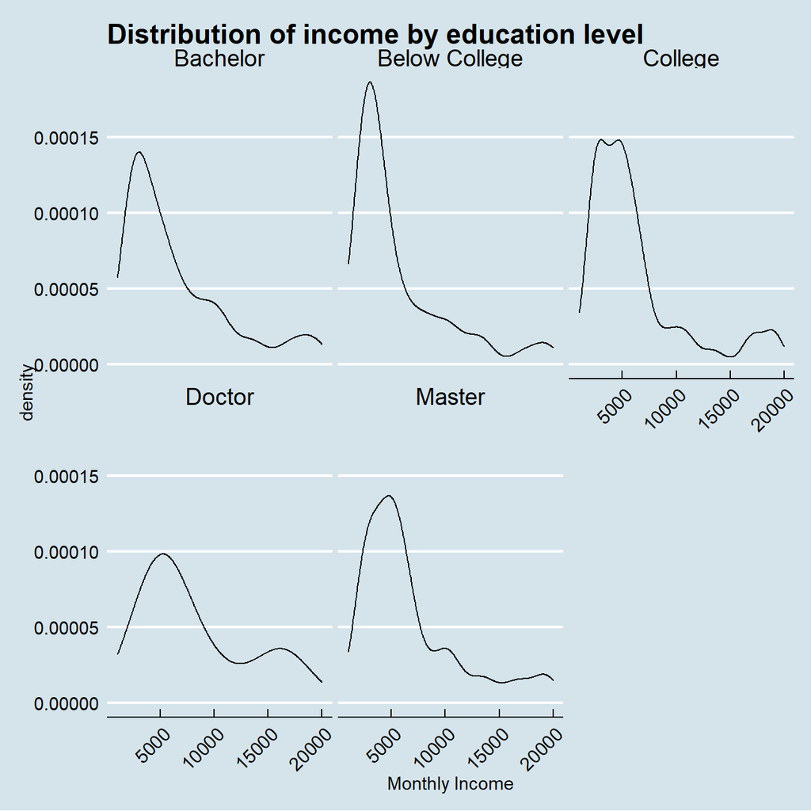

```r
ggplot(hr_cleaned, aes(x = monthly_income)) +
  geom_density() +
  facet_wrap(~education) +
  labs(title = "Distribution of income by education level",
  x = "Monthly Income") +
  theme_economist() +
  theme(axis.text.x = element_text(angle = 45 , vjust = 1, hjust=1)) +
  NULL
```

8. Relationship between Income and age, given a particular job role:

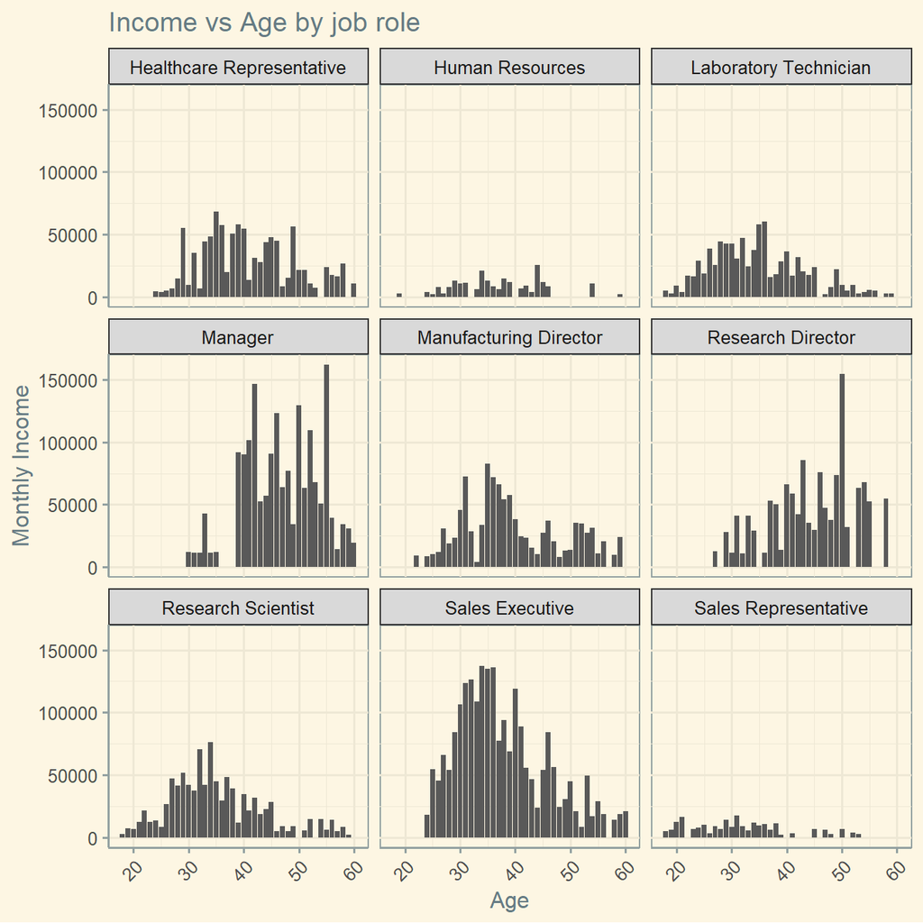

```r
ggplot(hr_cleaned, aes(x = age, y = monthly_income)) +
  geom_col() +
  facet_wrap(~job_role) +
  labs(title = "Income vs Age by job role",
  x = "Age",
  y = "Monthly Income") +
  theme_solarized() +
  theme(axis.text.x = element_text(angle = 45 , vjust = 1, hjust=1)) +
  NULL
```

# 5 Challenge 1: Replicating a chart

Image of White suicide rate vs White homicide rate:

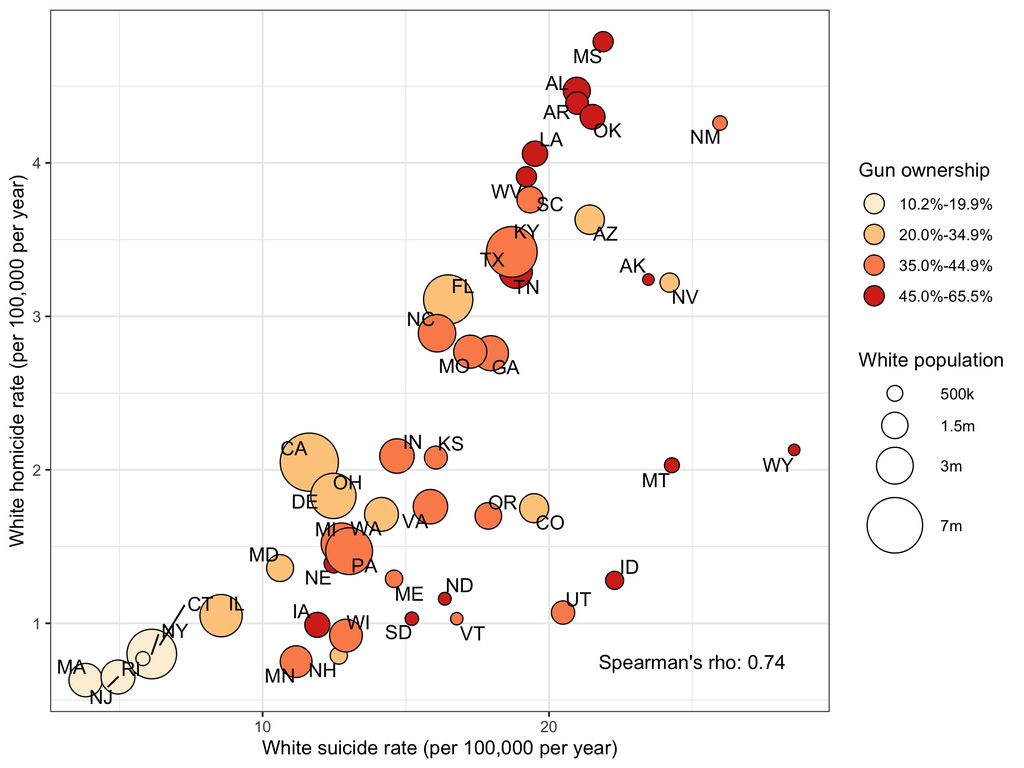

Generating the above image in R:

```r
# Replicate Figure 3

cdc_males <- read_csv(here::here("data", "CDC_males.csv"))
glimpse(cdc_males)
```

```
## Rows: 104
## Columns: 28
## $ ST                      <chr> "AK", "AK", "AL", "AL", "AR", "AR", "AZ", "...
## $ State                   <chr> "Alaska", "Alaska", "Alabama", "Alabama", "...
## $ Population.Black        <dbl> 153664, 153664, 5376635, 5376635, 1991165, ...
## $ Population.White        <dbl> 2274605, 2274605, 14267619, 14267619, 97470...
## $ Deaths.homicide.Black   <dbl> 23, NA, 183, 1812, 667, 90, 300, 40, 3712, ...
## $ Deaths.homicide.White   <dbl> 78, 10, 124, 620, 416, 110, 586, 145, 1399,...
## $ crude.homicide.Black    <dbl> 14.97, NA, 3.40, 33.70, 33.50, 4.52, 22.06,...
## $ crude.homicide.White    <dbl> 3.43, NA, 0.87, 4.35, 4.27, 1.13, 3.46, 0.8...
## $ adjusted.homicide.Black <dbl> 12.30, NA, 3.51, 33.00, 33.39, 4.81, 20.40,...
## $ adjusted.homicide.White <dbl> 3.24, NA, 0.85, 4.47, 4.39, 1.13, 3.63, 0.9...
## $ Deaths.suicide.Black    <dbl> 23, 12, 148, 370, 118, 75, 101, 80, 492, 63...
## $ Deaths.suicide.White    <dbl> 535, 196, 1222, 3195, 2154, 1027, 4146, 197...
## $ crude.suicide.Black     <dbl> 14.97, NA, 2.75, 6.88, 5.93, 3.77, 7.43, 5....
## $ crude.suicide.White     <dbl> 23.52, 8.62, 8.56, 22.39, 22.10, 10.54, 24....
## $ adjusted.suicide.Black  <dbl> 12.77, NA, 2.84, 7.20, 6.25, 3.93, 7.51, 5....
## $ adjusted.suicide.White  <dbl> 23.47, 8.21, 8.64, 20.97, 20.98, 10.89, 21....
## $ type                    <chr> "Firearm", "Non-Firearm", "Non-Firearm", "F...
## $ crude.RD.suicide        <dbl> -8.55, NA, -5.81, -15.51, -16.17, -6.77, -1...
## $ adj.RD.suicide          <dbl> -10.70, NA, -5.80, -13.77, -14.73, -6.96, -...
## $ crude.RD.homicide       <dbl> 11.54, NA, 2.53, 29.35, 29.23, 3.39, 18.60,...
## $ adj.RD.homicide         <dbl> 9.06, NA, 2.66, 28.53, 29.00, 3.68, 16.77, ...
## $ ST.order.RD.homicide    <chr> "AK", "AK", "AL", "AL", "AR", "AR", "AZ", "...
## $ ST.order.RD.suicide     <chr> "AK", "AK", "AL", "AL", "AR", "AR", "AZ", "...
## $ gun.house.prev          <dbl> 59.8, 59.8, 52.2, 52.2, 58.8, 58.8, 32.3, 3...
## $ gun.house.prev.category <chr> "45.0%-65.5%", "45.0%-65.5%", "45.0%-65.5%"...
## $ average.pop.white       <dbl> 252734, 252734, 1585291, 1585291, 1083003, ...
## $ average.pop.black       <dbl> 17074, 17074, 597404, 597404, 221241, 22124...
## $ type.fac                <chr> "Firearm-related", "Firearm-unrelated", "Fi...
```

```r
firearm_filtered <- cdc_males %>% filter(type == "Firearm" & !is.na(gun.house.prev.category))
glimpse(firearm_filtered)
```

```
## Rows: 50
## Columns: 28
## $ ST                      <chr> "AK", "AL", "AR", "AZ", "CA", "CO", "CT", "...
## $ State                   <chr> "Alaska", "Alabama", "Arkansas", "Arizona",...
## $ Population.Black        <dbl> 153664, 5376635, 1991165, 1360042, 10654017...
## $ Population.White        <dbl> 2274605, 14267619, 9747025, 16941107, 69327...
## $ Deaths.homicide.Black   <dbl> 23, 1812, 667, 300, 3712, 200, 373, 273, 38...
## $ Deaths.homicide.White   <dbl> 78, 620, 416, 586, 1399, 294, 96, 43, 1377,...
## $ crude.homicide.Black    <dbl> 15.0, 33.7, 33.5, 22.1, 34.8, 18.4, 23.7, 3...
## $ crude.homicide.White    <dbl> 3.43, 4.35, 4.27, 3.46, 2.02, 1.78, 0.86, 1...
## $ adjusted.homicide.Black <dbl> 12.3, 33.0, 33.4, 20.4, 32.3, 16.6, 21.4, 3...
## $ adjusted.homicide.White <dbl> 3.24, 4.47, 4.39, 3.63, 2.05, 1.75, 0.86, 1...
## $ Deaths.suicide.Black    <dbl> 23, 370, 118, 101, 492, 72, 35, 32, 621, 79...
## $ Deaths.suicide.White    <dbl> 535, 3195, 2154, 4146, 9563, 3404, 804, 356...
## $ crude.suicide.Black     <dbl> 14.97, 6.88, 5.93, 7.43, 4.62, 6.62, 2.22, ...
## $ crude.suicide.White     <dbl> 23.52, 22.39, 22.10, 24.47, 13.79, 20.59, 7...
## $ adjusted.suicide.Black  <dbl> 12.77, 7.20, 6.25, 7.51, 4.80, 6.49, 2.53, ...
## $ adjusted.suicide.White  <dbl> 23.47, 20.97, 20.98, 21.42, 11.63, 19.48, 6...
## $ type                    <chr> "Firearm", "Firearm", "Firearm", "Firearm",...
## $ crude.RD.suicide        <dbl> -8.55, -15.51, -16.17, -17.04, -9.17, -13.9...
## $ adj.RD.suicide          <dbl> -10.70, -13.77, -14.73, -13.91, -6.83, -12....
## $ crude.RD.homicide       <dbl> 11.5, 29.4, 29.2, 18.6, 32.8, 16.6, 22.8, 3...
## $ adj.RD.homicide         <dbl> 9.06, 28.53, 29.00, 16.77, 30.22, 14.81, 20...
## $ ST.order.RD.homicide    <chr> "AK", "AL", "AR", "AZ", "CA", "CO", "CT", "...
## $ ST.order.RD.suicide     <chr> "AK", "AL", "AR", "AZ", "CA", "CO", "CT", "...
## $ gun.house.prev          <dbl> 59.8, 52.2, 58.8, 32.3, 20.1, 34.6, 18.1, 2...
## $ gun.house.prev.category <chr> "45.0%-65.5%", "45.0%-65.5%", "45.0%-65.5%"...
## $ average.pop.white       <dbl> 252734, 1585291, 1083003, 1882345, 7703022,...
## $ average.pop.black       <dbl> 17074, 597404, 221241, 151116, 1183780, 120...
## $ type.fac                <chr> "Firearm-related", "Firearm-related", "Fire...
```

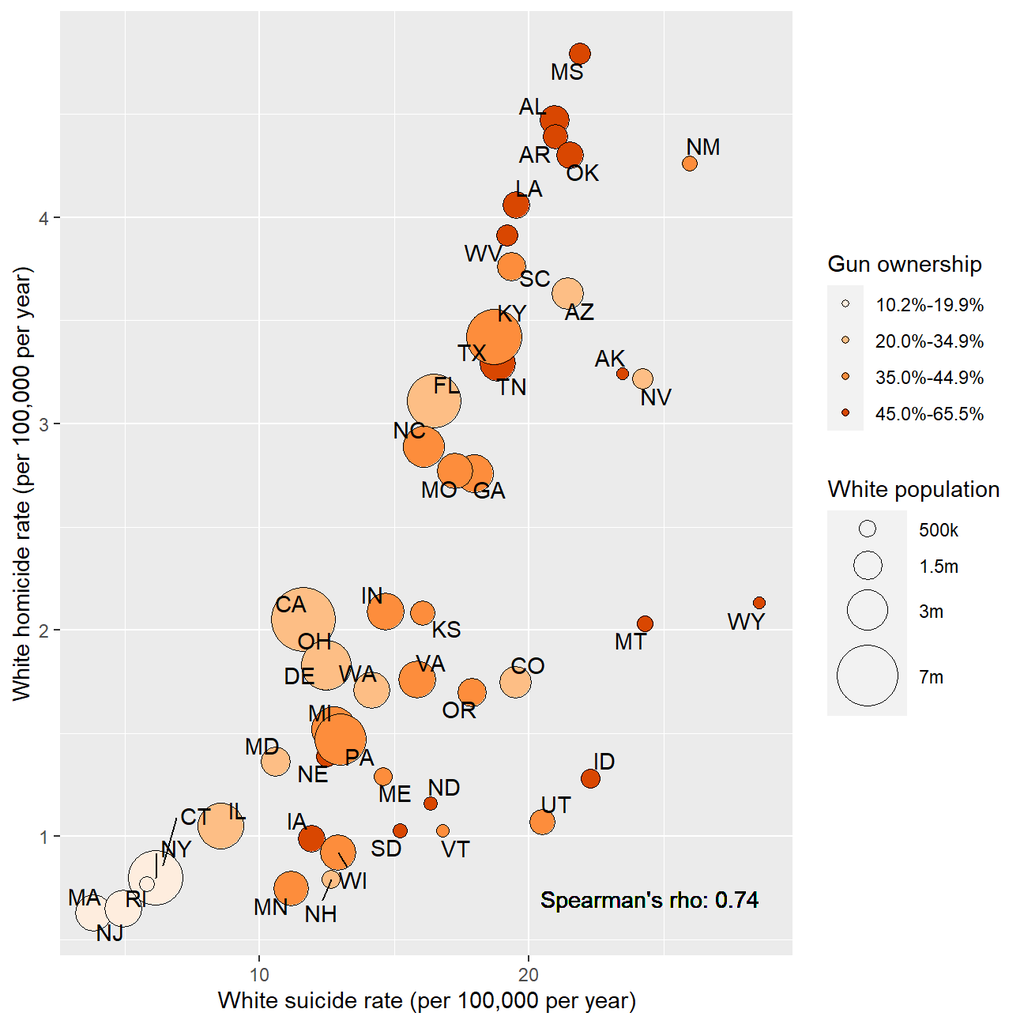

```r
ggplot(firearm_filtered, aes(x=adjusted.suicide.White, y=adjusted.homicide.White)) +
  geom_point(aes(size = firearm_filtered$average.pop.white,
                 fill = firearm_filtered$gun.house.prev.category), color = "black", pch = 21) +
  scale_color_manual(values = c("#feedde", "#fdbe85", "#fd8d3c", "#d94701"), aesthetics = c("fill")) +
  labs(x='White suicide rate (per 100,000 per year)',
       y='White homicide rate (per 100,000 per year)') +
  scale_size_area(breaks = c(500000, 1500000, 3000000, 7000000),
                  labels = c('500k', '1.5m', '3m', '7m'), max_size = 14) +
  geom_text_repel(label = firearm_filtered$ST) +
  geom_text(label = "Spearman's rho: 0.74", x = 24.5, y = 0.7) +
  guides(fill = guide_legend(title = "Gun ownership", order = 1),
         size = guide_legend(title = "White population", order = 2)) +
  NULL
```

```r
# Sources:
# https://stackoverflow.com/questions/10437442/place-a-border-around-points
# https://stackoverflow.com/questions/40211451/geom-text-how-to-position-the-text-on-bar-as-i-want
# https://ggplot2.tidyverse.org/reference/scale_manual.html
# https://ggplot2.tidyverse.org/reference/guides.html
```

# 6 Challenge 2: 2016 California Contributors plots

Image showing “Where did candidates raise most money in US elections?”:

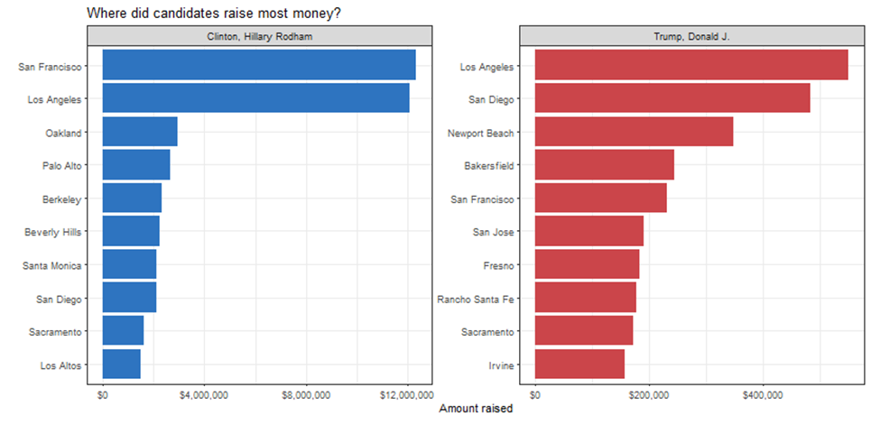

Generating the above image in R:

```r
# Make sure you use vroom() as it is significantly faster than read.csv()
CA_contributors_2016 <- vroom::vroom(here::here("data","CA_contributors_2016.csv"))
zipcodes_db <- vroom::vroom(here::here("zip_code_database.csv"))
zipcodes_db$zip <- as.numeric(zipcodes_db$zip)
zipcodes <- zipcodes_db %>% select(zip, primary_city)

glimpse(CA_contributors_2016)
```

```
## Rows: 1,292,843
## Columns: 4
## $ cand_nm           <chr> "Clinton, Hillary Rodham", "Clinton, Hillary Rodh...
## $ contb_receipt_amt <dbl> 50.0, 200.0, 5.0, 48.3, 40.0, 244.3, 35.0, 100.0,...
## $ zip               <dbl> 94939, 93428, 92337, 95334, 93011, 95826, 90278, ...
## $ contb_date        <date> 2016-04-26, 2016-04-20, 2016-04-02, 2016-11-21, ...
```

```r
glimpse(zipcodes_db)
```

```
## Rows: 42,522
## Columns: 16
## $ zip                  <dbl> 501, 544, 601, 602, 603, 604, 605, 606, 610, 6...
## $ type                 <chr> "UNIQUE", "UNIQUE", "STANDARD", "STANDARD", "S...
## $ primary_city         <chr> "Holtsville", "Holtsville", "Adjuntas", "Aguad...
## $ acceptable_cities    <chr> NA, NA, NA, NA, "Ramey", "Ramey", NA, NA, NA, ...
## $ unacceptable_cities  <chr> "I R S Service Center", "Irs Service Center", ...
## $ state                <chr> "NY", "NY", "PR", "PR", "PR", "PR", "PR", "PR"...
## $ county               <chr> "Suffolk County", "Suffolk County", "Adjuntas"...
## $ timezone             <chr> "America/New_York", "America/New_York", "Ameri...
## $ area_codes           <dbl> 631, 631, 787939, 787, 787, NA, NA, 787939, 78...
## $ latitude             <dbl> 40.8, 40.8, 18.2, 18.4, 18.4, 18.4, 18.4, 18.2...
## $ longitude            <dbl> -73.0, -73.0, -66.7, -67.2, -67.2, -67.2, -67....
## $ world_region         <chr> NA, NA, NA, NA, NA, NA, NA, NA, NA, NA, NA, NA...
## $ country              <chr> "US", "US", "US", "US", "US", "US", "US", "US"...
## $ decommissioned       <dbl> 0, 0, 0, 0, 0, 0, 0, 0, 0, 0, 0, 0, 0, 0, 0, 0...
## $ estimated_population <dbl> 384, 0, 0, 0, 0, 0, 0, 0, 0, 0, 0, 0, 0, 0, 0,...
## $ notes                <chr> NA, NA, NA, NA, NA, NA, NA, NA, NA, "no NWS da...
```

```r
contributors_with_city <- CA_contributors_2016 %>%  left_join(zipcodes, by = "zip")
glimpse(contributors_with_city)
```

```
## Rows: 1,292,843
## Columns: 5
## $ cand_nm           <chr> "Clinton, Hillary Rodham", "Clinton, Hillary Rodh...
## $ contb_receipt_amt <dbl> 50.0, 200.0, 5.0, 48.3, 40.0, 244.3, 35.0, 100.0,...
## $ zip               <dbl> 94939, 93428, 92337, 95334, 93011, 95826, 90278, ...
## $ contb_date        <date> 2016-04-26, 2016-04-20, 2016-04-02, 2016-11-21, ...
## $ primary_city      <chr> "Larkspur", "Cambria", "Fontana", "Livingston", "...
```

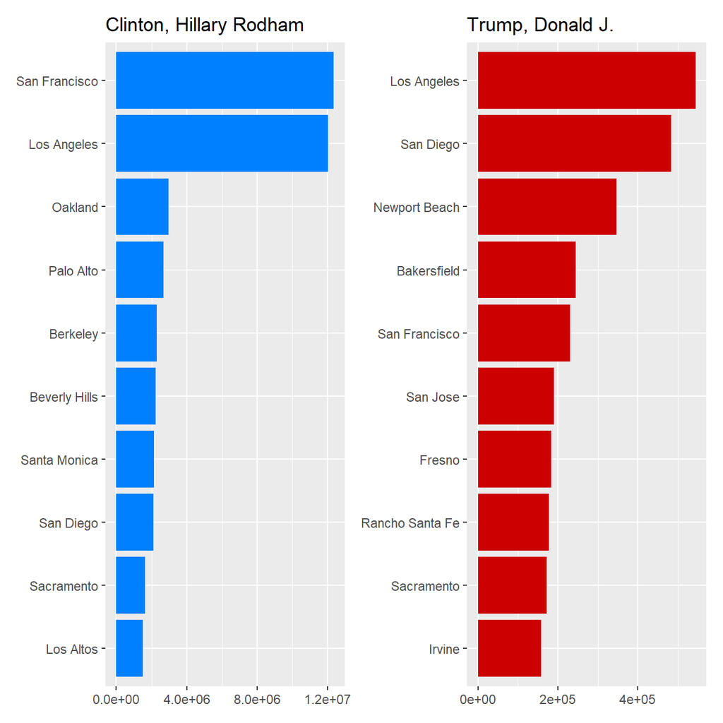

```r
tbl_Hillary <- contributors_with_city %>% filter(cand_nm == "Clinton, Hillary Rodham") %>%
  group_by(primary_city) %>% summarise(city_contribution = sum(contb_receipt_amt)) %>%
  arrange(desc(city_contribution)) %>% mutate(cand_nm = "Clinton, Hillary Rodham") %>% head(10)
plot_Hillary <- ggplot(tbl_Hillary, aes(x=reorder(primary_city, city_contribution), y=city_contribution,
                                        fill = cand_nm)) +
  scale_color_manual(values = c("#0080ff"), aesthetics = c("fill")) +
  labs(title = "Clinton, Hillary Rodham", x = NULL, y = NULL) +
  geom_col(show.legend = FALSE) + coord_flip() + NULL

tbl_Donald <- contributors_with_city %>% filter(cand_nm == "Trump, Donald J.") %>%
  group_by(primary_city) %>% summarise(city_contribution = sum(contb_receipt_amt)) %>%
  arrange(desc(city_contribution)) %>% mutate(cand_nm = "Trump, Donald J.")  %>% head(10)
plot_Donald <- ggplot(tbl_Donald, aes(x=reorder(primary_city, city_contribution), y=city_contribution,
                       fill = cand_nm)) +
  scale_color_manual(values = c("#cc0000"), aesthetics = c("fill")) +
  labs(title = "Trump, Donald J.", x = NULL, y = NULL) +
  geom_col(show.legend = FALSE) + coord_flip() + NULL


plot_Hillary + plot_Donald
```

Generating the similar image for Top 10 candidates:

```r
top_10_candidate_names <- contributors_with_city %>% group_by(cand_nm) %>%
  summarise(sum_contribution = sum(contb_receipt_amt)) %>% arrange(desc(sum_contribution)) %>% head(10) %>%
  select(cand_nm)
top_10_candidate_names
```

```
## # A tibble: 10 x 1
##    cand_nm
##    <chr>
##  1 Clinton, Hillary Rodham
##  2 Sanders, Bernard
##  3 Trump, Donald J.
##  4 Cruz, Rafael Edward 'Ted'
##  5 Rubio, Marco
##  6 Bush, Jeb
##  7 Carson, Benjamin S.
##  8 Kasich, John R.
##  9 Fiorina, Carly
## 10 Paul, Rand
```

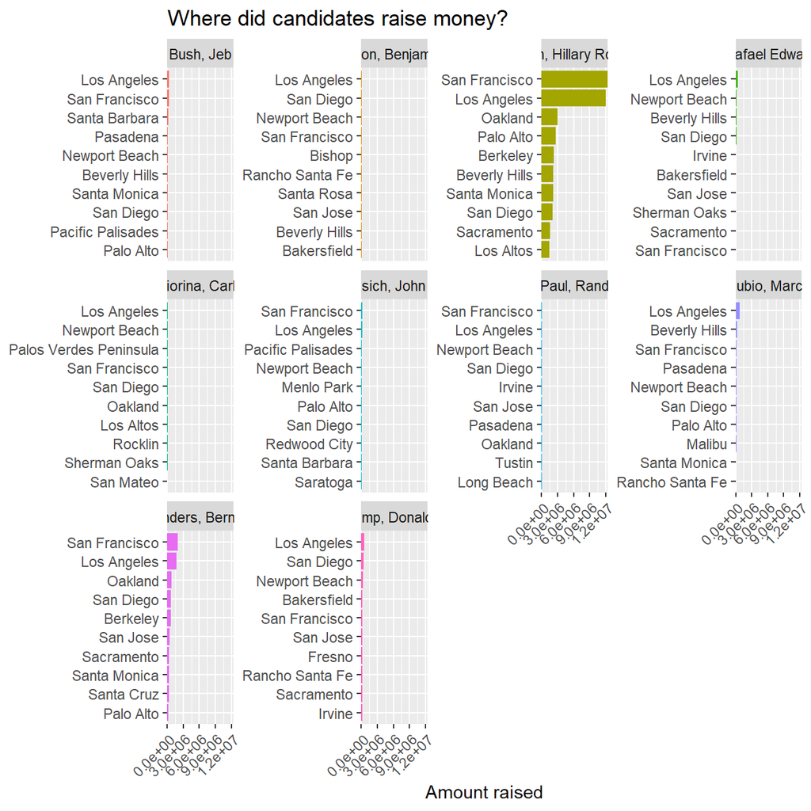

```r
db_candidate_and_city <- contributors_with_city %>% filter(cand_nm %in% top_10_candidate_names$cand_nm) %>%
  group_by(cand_nm, primary_city) %>% summarise(city_contribution = sum(contb_receipt_amt)) %>% ungroup

db_candidate_and_city %>% group_by(cand_nm) %>% top_n(10) %>% ungroup %>%
  mutate(cand_nm = as.factor(cand_nm),
         primary_city = reorder_within(primary_city, city_contribution, cand_nm)) %>%
  ggplot(aes(primary_city, city_contribution, fill = cand_nm)) +
  geom_col(show.legend = FALSE) +
  facet_wrap(~cand_nm, scales = "free_y") +
  coord_flip() +
  scale_x_reordered() +
  scale_y_continuous(expand = c(0,0)) +
  labs(y = "Amount raised",
       x = NULL,
       title = "Where did candidates raise money?") +
  theme(axis.text.x = element_text(angle = 45 , vjust = 1, hjust=1)) +
  NULL
```

# 7 Details

- Who did you collaborate with: DEEPAK GUNEJA, WARREN HU, JUSTINE VEYRENC, RICCARDO PERSICO, ALEX SKLAVOUNOS, CHENYING LI
- Approximately how much time did you spend on this problem set: 10 HOURS
- What, if anything, gave you the most trouble: FINDING WHY THERE WERE ERRORS